# R Basics: Notes and Exercises

Module 0 — DATASCI 406, Computational Methods in Statistics and Data Science

Mark M. Fredrickson (mfredric@umich.edu)

# 1. RMarkdown

Plain text with **structured prose** and **embedded R**. Knitting runs the R and drops the results — values, tables, plots — into the output.

The payoff: **the number in your prose and the number in your computation cannot disagree.**

A **code chunk** runs R and shows both code and result:

```r
17 * 3
```

```
#> [1] 51
```

**Chunk options** control what appears — `echo = FALSE` hides the code, `include = FALSE` hides both but still runs, `eval = FALSE` shows without running:

````
```
#> [1] 51
```
````

```
#> [1] 51
```

**Inline code** puts a value in a sentence. `` `r 17 * 3` `` gives: 17 times 3 is 51.

## Exercise

Using `Help -> Cheatsheets -> R Markdown Reference Guide`, add each of these to this document:

- Bold and italic text
- A header one level smaller than “Exercise” above
- A link to https://www.umich.edu
- A blockquote holding these two lines from Shakespeare’s Sonnet 52:
  - Blessed are you whose worthiness gives scope,
  - Being had, to triumph, being lacked, to hope.
- A numbered list with three elements, one having a bulleted sublist
- The `um_logo.png` file that ships with this document, as an image
- A table of states with capitals and state flowers: Michigan/Lansing/Apple blossom, Ohio/Columbus/Carnation, Wisconsin/Madison/Wood violet

### Solution

**Bold** and *italic*.

#### A smaller header

A link to [the University of Michigan](https://www.umich.edu).

> Blessed are you whose worthiness gives scope,

> Being had, to triumph, being lacked, to hope.
1. This
2. is a numbered list
3. whose last element has a sublist
   - of
   - bullet
   - points

[figure not shown]

The University of Michigan logo

| State | Capital | State flower |
| --- | --- | --- |
| Michigan | Lansing | Apple blossom |
| Ohio | Columbus | Carnation |
| Wisconsin | Madison | Wood violet |

# 2. Getting help

Every R function has a help page, and it is the answer to most questions.

```r
?t.test          # a function you can name
??"Student"      # search all help pages for a phrase
?Arithmetic      # topics, not just functions
```

Read a help page **Usage** first — argument names and defaults — then **Arguments**, then the **Examples** at the bottom, which you can copy and run.

`Help -> Cheatsheets` has one-page summaries of RMarkdown, `dplyr`, and `ggplot2`.

Searching the web for R is hard because “R” is a letter. Put a function name in the query, not the language.

# 3. Variables and arithmetic

Assignment uses `<-`. Names start with a letter and may contain letters, digits, `.`, and `_`.

```r
a1 <- 3
b_2 <- 4
C.3 <- a1 * b_2 + a1 / b_2
C.3
```

```
#> [1] 12.75
```

`=` also assigns, and `==` asks about equality.

```r
x1 <- 1
x2 = 1
x1 == x2
```

```
#> [1] TRUE
```

I recommend `<-`: it cannot be mistaken for an equality check, and it reverses.

```r
2 -> x3
x3
```

```
#> [1] 2
```

Arithmetic is what you expect, with the usual precedence:

```r
2 + 9 / 3
```

```
#> [1] 5
```

```r
(2 + 9) / 3
```

```
#> [1] 3.666667
```

Anything beyond arithmetic is a **function**, called as `name(arg1, arg2)`:

```r
sqrt(2)
```

```
#> [1] 1.414214
```

```r
exp(1)
```

```
#> [1] 2.718282
```

```r
log(10)
```

```
#> [1] 2.302585
```

Arguments have names and can be supplied by name in any order. `?log` gives the usage as `log(x, base = exp(1))`, so `base` has a **default** and is optional.

```r
log(64, base = 2)
```

```
#> [1] 6
```

```r
log(base = 2, x = 64)
```

```
#> [1] 6
```

R has a few built-in constants. We will use `pi` constantly:

```r
pi
```

```
#> [1] 3.141593
```

R tells you when a variable does not exist, and the assignment does not happen either:

```r
d <- a7 + 1
```

```
#> Error:
#> ! object 'a7' not found
```

```r
d
```

```
#> Error:
#> ! object 'd' not found
```

That means a typo, or lines run out of order.

## Exercise

Using the built-in `pi`:

1. Compute the area and circumference of a circle of radius 3.
2. Compute $1/\sqrt{2\pi}$ — the height of the standard Normal density at zero.
3. Save the area to a variable and report it, rounded to two decimals, in a sentence using **inline** R.

**Expected output:**

| area | 28.27433 |
| --- | --- |
| circumference | 18.84956 |
| $1/\sqrt{2\pi}$ | 0.3989423 |

### Solution

```r
r <- 3
(area <- pi * r^2)
```

```
#> [1] 28.27433
```

```r
2 * pi * r
```

```
#> [1] 18.84956
```

```r
1 / sqrt(2 * pi)
```

```
#> [1] 0.3989423
```

`` `r round(area, 2)` `` gives:

> A circle of radius 3 has area 28.27.

The radius is written once, so changing it changes every number — including the one in the sentence.

# 4. Vectors

Almost all data in R is a **vector** with a length. There are no scalars; a single number is a vector of length one.

```r
length(99)
```

```
#> [1] 1
```

`c()` combines values. Arithmetic applies **element by element**, and a length-one vector is stretched to fit (“recycled”):

```r
some_odds <- c(7, 9, 11, 13)
some_odds + some_odds
```

```
#> [1] 14 18 22 26
```

```r
2 * some_odds
```

```
#> [1] 14 18 22 26
```

This is **vectorization**. When the mathematics says “for each $i$”, R usually lets you write it without saying “for each $i$”.

Sequences come from `:` and `seq()`; many functions take a vector and return one number:

```r
1:5
```

```
#> [1] 1 2 3 4 5
```

```r
seq(1, 10, by = 2)
```

```
#> [1] 1 3 5 7 9
```

```r
sum(1:10)
```

```
#> [1] 55
```

Every element has the same type, and logicals count as numbers with `TRUE` as 1:

```r
c(2.0, 7.1, -0.0002)
```

```
#> [1]  2.0000  7.1000 -0.0002
```

```r
c("This", "is", "a", "vector")
```

```
#> [1] "This"   "is"     "a"      "vector"
```

```r
sum(c(TRUE, FALSE, FALSE, TRUE))
```

```
#> [1] 2
```

A very useful property: `sum(condition)` counts, `mean(condition)` gives the proportion.

```r
mean(c(2.0, 7.1, -0.0002) > 1)
```

```
#> [1] 0.6666667
```

Square brackets extract, by position or by condition:

```r
letters[c(1, 5, 9, 15, 21)]
```

```
#> [1] "a" "e" "i" "o" "u"
```

```r
some_odds[some_odds > 9]
```

```
#> [1] 11 13
```

## Exercise

There are several series approximations to $\pi$. The **Madhava–Leibniz series**, found in Kerala in the 14th century and again in Europe in the 17th:

$$\frac{\pi}{4} = 1 - \frac13 + \frac15 -
\frac17 + \frac19 - \cdots
= \sum_{k=1}^{\infty} \frac{(-1)^{k-1}}{2k-1}$$

Create the first 5 terms with a vectorized computation, add them with `sum()`, and multiply by 4.

```r
k <- 1:5 # the digits 1, 2, 3, 4, 5 as a vector
```

### Solution

```r
k <- 1:5
terms <- (-1)^(k - 1) / (2 * k - 1)
terms
```

```
#> [1]  1.0000000 -0.3333333  0.2000000 -0.1428571  0.1111111
```

```r
4 * sum(terms)
```

```
#> [1] 3.339683
```

`3.34` against a true value of 3.1416. Not great.

# 5. Lists

A vector holds one type. A **list** holds anything, including other lists:

```r
ll <- list("A", 7, TRUE)
```

Two extraction operators, and the difference matters:

```r
ll[3]         # single brackets: a LIST of length 1
```

```
#> [[1]]
#> [1] TRUE
```

```r
class(ll[3])
```

```
#> [1] "list"
```

```r
ll[[3]]       # double brackets: the THING inside
```

```
#> [1] TRUE
```

```r
class(ll[[3]])
```

```
#> [1] "logical"
```

Single brackets return the same kind of container; double brackets reach inside. When something “isn’t a number” and you are sure it is, this is usually why.

Named lists also take `$`:

```r
luke <- list(father = "Anakin", mother = "Amidala")
luke$father
```

```
#> [1] "Anakin"
```

Lists matter because a function returning several things returns a list — how every fitting routine in R hands you results:

```r
fit <- lm(hwy ~ displ, data = mpg)
class(fit)
```

```
#> [1] "lm"
```

```r
fit$coefficients
```

```
#> (Intercept)       displ
#>   35.697651   -3.530589
```

# 6. Writing functions

A function is an object, created by assignment. The last expression is returned, so `return()` is optional:

```r
square <- function(x) {
  x^2
}
square(4)
```

```
#> [1] 16
```

The body is ordinary R, so functions are **vectorized for free**:

```r
square(1:5)
```

```
#> [1]  1  4  9 16 25
```

Arguments can have defaults, and can be passed by name in any order:

```r
greet <- function(name, opening = "Hello") {
  paste0(opening, ", ", name, ".")
}
greet("Ernie")
```

```
#> [1] "Hello, Ernie."
```

```r
greet("Ernie", opening = "Good morning")
```

```
#> [1] "Good morning, Ernie."
```

```r
greet(opening = "Bonjour", name = "Bert")
```

```
#> [1] "Bonjour, Bert."
```

Functions have their own scope — assigning to `x` inside does not touch the `x` outside:

```r
x <- "hello"
f <- function(x) {
  x <- x + 1
  x^2
}
f(7)
```

```
#> [1] 64
```

```r
x
```

```
#> [1] "hello"
```

But a function that *reads* a variable it was not given will find it outside, and change behaviour when that variable changes:

```r
y <- 127
g <- function(x) x + y
g(1)
```

```
#> [1] 128
```

```r
y <- -1
g(1)
```

```
#> [1] 0
```

Same call, two answers, and nothing in `g` changed. **Pass everything a function needs as an argument.**

## Exercise

Write `S(n)` returning the **partial sum** after `n` terms,

$$S(n) = \sum_{k=1}^{n}
\frac{(-1)^{k-1}}{2k-1}$$

vectorized, no loop. Give it a second argument `scale` defaulting to 4, so `S(n)` estimates $\pi$ directly and `S(n, scale = 1)` gives the raw sum.

**Expected output:**

| `S(1)` | 4 |
| --- | --- |
| `S(2)` | 2.666667 |
| `S(5)` | 3.339683 |
| `S(5, scale = 1)` | 0.8349206 |
| `S(1000)` | 3.140593 |

### Solution

```r
S <- function(n, scale = 4) {
  k <- 1:n
  scale * sum((-1)^(k - 1) / (2 * k - 1))
}

c(S(1), S(2), S(5), S(5, scale = 1), S(1000))
```

```
#> [1] 4.0000000 2.6666667 3.3396825 0.8349206 3.1405927
```

`n` is an argument, not read from outside, so `S` is safe to reuse. And the “sum over $k$” in the mathematics is a `sum()` over a vector in the code.

# 7. Iteration: `for` and `map`

Vectorization handles most of what a loop would do. Use real iteration when each step depends on the last, or when calling a function repeatedly.

```r
for (animal in c("tiger", "llama", "cat")) {
  print(paste("my favorite animal is", animal))
}
```

```
#> [1] "my favorite animal is tiger"
#> [1] "my favorite animal is llama"
#> [1] "my favorite animal is cat"
```

To collect results, **allocate the container first**. Growing one with `c()` inside a loop copies it every pass, turning a linear job into a quadratic one:

```r
estimates <- numeric(5)          # allocate, do not grow
for (i in 1:5) {
  estimates[i] <- S(i)
}
estimates
```

```
#> [1] 4.000000 2.666667 3.466667 2.895238 3.339683
```

Usually a helper iterates for you. `map()` returns a list; the typed variants return a vector:

```r
map_dbl(1:5, S)
```

```
#> [1] 4.000000 2.666667 3.466667 2.895238 3.339683
```

The `~ .x` form writes a short anonymous function inline:

```r
map_dbl(1:5, ~ S(.x) - pi)
```

```
#> [1]  0.8584073 -0.4749260  0.3250740 -0.2463546  0.1980899
```

The rest of the family, worth knowing by name:

```r
reduce(1:10, `+`)                     # collapse to one value
```

```
#> [1] 55
```

```r
accumulate(1:5, `+`)                  # ... showing every step
```

```
#> [1]  1  3  6 10 15
```

```r
keep(1:10, ~ .x %% 2 == 0)            # select
```

```
#> [1]  2  4  6  8 10
```

```r
discard(1:10, ~ .x %% 2 == 0)         # reject
```

```
#> [1] 1 3 5 7 9
```

```r
map2_chr(c("red", "green"), c("whale", "ostrich"), paste)   # two at once
```

```
#> [1] "red whale"     "green ostrich"
```

## Exercise

Use `map_dbl()` to get the error `S(n) - pi` for `n = 1, 10, 100, 1000, 10000, 100000`.

Then: **what simple formula in `n` do the errors follow?** Confirm by dividing.

**Expected output:**

| `n` | error |
| --- | --- |
| 1 | +8.585e-01 |
| 10 | −9.975e-02 |
| 100 | −1.000e-02 |
| 1000 | −1.000e-03 |
| 10000 | −1.000e-04 |
| 100000 | −1.000e-05 |

### Solution

```r
ns <- 10^(0:5)
errs <- map_dbl(ns, ~ S(.x) - pi)
signif(errs, 4)
```

```
#> [1]  0.85840 -0.09975 -0.01000 -0.00100 -0.00010 -0.00001
```

The magnitude is $1/n$:

```r
errs * ns
```

```
#> [1]  0.8584073 -0.9975303 -0.9999750 -0.9999997 -1.0000000 -1.0000000
```

The sign is negative only because these `n` are even; in general the error is $(-1)^n/n$. **The magnitude is $1/n$** — ten times the work buys one more correct digit.

Ten digits would need $10^{10}$ terms. Better series exist; Module 4 goes looking. For now, note that you *measured* the rate rather than guessed it.

# 8. Conditions: `if` and `while`

Both take the same kind of argument: a single `TRUE` or `FALSE`. `if` asks once, `while` asks over and over.

## `if`

```r
x <- 7

if (x > 5) {
  "big"
} else {
  "small"
}
```

```
#> [1] "big"
```

`else if` chains branches, and since the last expression is returned, this is often all a function needs to be:

```r
letter_grade <- function(score) {
  if (score >= 90) {
    "A"
  } else if (score >= 80) {
    "B"
  } else {
    "C"
  }
}

c(letter_grade(95), letter_grade(85), letter_grade(70))
```

```
#> [1] "A" "B" "C"
```

## `if` wants exactly one `TRUE` or `FALSE`

The first error most people hit, and a direct consequence of Section 4: **everything is a vector.**

```r
v <- c(1, 5, 9)
if (v > 4) "yes" else "no"
```

```
#> Error in `if (v > 4) ...`:
#> ! the condition has length > 1
```

`v > 4` is three logicals and `if` cannot act on three answers at once. This is an **error**, not a warning — it was only a warning before R 4.2, so older advice will disagree with your console.

The fix depends on which of two things you meant.

**One answer about the whole vector** — reduce it first:

```r
any(v > 4)      # true anywhere?
```

```
#> [1] TRUE
```

```r
all(v > 4)      # true everywhere?
```

```
#> [1] FALSE
```

```r
sum(v > 4)      # how many?
```

```
#> [1] 2
```

**One answer per element** — then you do not want `if` at all, you want the vectorized `ifelse()`:

```r
ifelse(v > 4, "yes", "no")
```

```
#> [1] "no"  "yes" "yes"
```

Same split in the operators: `&` and `|` work element by element, `&&` and `||` give one answer and belong in an `if`.

```r
c(TRUE, TRUE) & c(TRUE, FALSE)
```

```
#> [1]  TRUE FALSE
```

```r
TRUE && FALSE
```

```
#> [1] FALSE
```

```r
c(TRUE, TRUE) && TRUE
```

```
#> Error in `c(TRUE, TRUE) && TRUE`:
#> ! 'length = 2' in coercion to 'logical(1)'
```

Two more conditions R refuses:

```r
if (NA > 1) "yes"
```

```
#> Error in `if (NA > 1) ...`:
#> ! missing value where TRUE/FALSE needed
```

```r
if (NULL) "yes"
```

```
#> Error in `if (NULL) ...`:
#> ! argument is of length zero
```

The `NA` one bites in practice: `if (mean(x) > 0)` can work all term and then fail on the one dataset with an `NA` in it. That is a feature — the alternative is quietly taking the wrong branch.

## `while`

The same question, asked before every pass. A `for` loop runs a known number of times; a `while` loop runs until its condition goes false.

```r
x <- 1
halvings <- 0

while (x > 1e-3) {
  x <- x / 2
  halvings <- halvings + 1
}

halvings
```

```
#> [1] 10
```

```r
x
```

```
#> [1] 0.0009765625
```

Every iterative method in Module 4 has this shape: improve the guess until it stops changing.

**Guard every `while` loop** — nothing enforces that the condition will ever go false, and an unguarded loop that does not converge hangs your session. Note that the guard is itself an `if`:

```r
while (not_there_yet) {
  if (iter >= max_iter) stop("no convergence in ", max_iter, " iterations")
  # ... improve the guess ...
  iter <- iter + 1
}
```

## Exercise

Keep adding terms until the term you just added is small, then stop. You do not know how many terms that takes, so it is a `while` loop.

Write `pi_while(tol)` returning the number of terms used, the estimate, and the error. Run it for `tol` of `1e-1`, `1e-2`, `1e-3`, `1e-4`, `1e-5`.

Then: **you asked for `tol`. What accuracy did you get?**

**Expected output:**

| `tol` | terms | $\hat\pi$ | error |
| --- | --- | --- | --- |
| 1e-1 | 6 | 2.976046 | −1.655e-01 |
| 1e-2 | 51 | 3.161199 | +1.961e-02 |
| 1e-3 | 501 | 3.143589 | +1.996e-03 |
| 1e-4 | 5001 | 3.141793 | +2.000e-04 |
| 1e-5 | 50001 | 3.141613 | +2.000e-05 |

### Solution

```r
pi_while <- function(tol, max_iter = 1e7) {
  total <- 0
  term <- Inf
  k <- 1

  while (abs(term) > tol) {
    if (k > max_iter) stop("no convergence in ", max_iter, " terms")
    term <- (-1)^(k - 1) / (2 * k - 1)
    total <- total + term
    k <- k + 1
  }

  c(terms = k - 1, pi_hat = 4 * total, error = 4 * total - pi)
}

sapply(c(1e-1, 1e-2, 1e-3, 1e-4, 1e-5), pi_while)
```

```
#>              [,1]        [,2]         [,3]         [,4]         [,5]
#> terms   6.0000000 51.00000000 5.010000e+02 5.001000e+03 5.000100e+04
#> pi_hat  2.9760462  3.16119861 3.143589e+00 3.141793e+00 3.141613e+00
#> error  -0.1655465  0.01960596 1.996006e-03 1.999600e-04 1.999960e-05
```

Both conditions are in there: the `while` asks whether the last term is still too big, the `if` asks whether we have gone on too long.

Here they happen to be related, because the series alternates with shrinking terms, so the error is bounded by the first term left out. Module 4 takes this up for methods where it is harder.

# 9. Data frames

We have a range of `n` and an error at each: two parallel vectors. That is what a **data frame** is — a list of equal-length vectors read as columns.

`tibble()` is the tidyverse’s data frame; `mutate()` adds columns computed from existing ones:

```r
convergence <- tibble(n = unique(round(10^seq(0, 3, by = 0.1)))) |>
  mutate(estimate = map_dbl(n, S),
         error    = abs(estimate - pi))

convergence
```

```
#> # A tibble: 28 × 3
#>        n estimate  error
#>    <dbl>    <dbl>  <dbl>
#>  1     1     4    0.858
#>  2     2     2.67 0.475
#>  3     3     3.47 0.325
#>  4     4     2.90 0.246
#>  5     5     3.34 0.198
#>  6     6     2.98 0.166
#>  7     8     3.02 0.125
#>  8    10     3.04 0.0998
#>  9    13     3.22 0.0768
#> 10    16     3.08 0.0624
#> # ℹ 18 more rows
```

The `|>` is the **pipe**: `x |> f(y)` means `f(x, y)`, so a chain reads left to right instead of inside out.

A data frame is a list of vectors, so list notation works, and so does matrix-style indexing:

```r
convergence$n[1:5]      # a column, as a vector
```

```
#> [1] 1 2 3 4 5
```

```r
convergence[3, 2]       # row 3, column 2
```

```
#> # A tibble: 1 × 1
#>   estimate
#>      <dbl>
#> 1     3.47
```

```r
convergence[3, ]        # all of row 3
```

```
#> # A tibble: 1 × 3
#>       n estimate error
#>   <dbl>    <dbl> <dbl>
#> 1     3     3.47 0.325
```

The `dplyr` verbs each take a data frame and return one, which is why they chain:

```r
convergence |>
  filter(n >= 100) |>
  mutate(digits = -log10(error)) |>
  select(n, estimate, error, digits) |>
  arrange(desc(digits)) |>
  head(3)
```

```
#> # A tibble: 3 × 4
#>       n estimate    error digits
#>   <dbl>    <dbl>    <dbl>  <dbl>
#> 1  1000     3.14 0.001000   3.00
#> 2   794     3.14 0.00126    2.90
#> 3   631     3.14 0.00158    2.80
```

A thousand terms buys three digits — the $1/n$ rate from Section 7, in digits.

`group_by()` plus `summarize()` computes per group instead of per table:

```r
mpg |>
  group_by(cyl) |>
  summarize(n = n(), mean_hwy = mean(hwy), sd_hwy = sd(hwy))
```

```
#> # A tibble: 4 × 4
#>     cyl     n mean_hwy sd_hwy
#>   <int> <int>    <dbl>  <dbl>
#> 1     4    81     28.8   4.52
#> 2     5     4     28.8   0.5
#> 3     6    79     22.8   3.69
#> 4     8    70     17.6   3.26
```

## Exercise

The `starwars` data loads with the tidyverse.

- How many characters, and how many columns?
- What type is the `species` column?
- What does `NA` in `hair_color` mean? Not a computation — a question about what the data records.
- How many characters are from Tatooine?
- Among humans, what is the mean `birth_year`?

Hints: `TRUE` counts as 1 inside `sum()`, and most summary functions take `na.rm = TRUE`.

**Expected output:**

| characters | 87 |
| --- | --- |
| columns | 14 |
| `NA` in `hair_color` | 5 |
| from Tatooine | 10 |
| mean human `birth_year` | **53.7423** |

### Solution

```r
dim(starwars)
```

```
#> [1] 87 14
```

```r
class(starwars$species)
```

```
#> [1] "character"
```

```r
sum(is.na(starwars$hair_color))
```

```
#> [1] 5
```

```r
sum(starwars$homeworld == "Tatooine", na.rm = TRUE)
```

```
#> [1] 10
```

```r
mean(starwars$birth_year[starwars$species == "Human"], na.rm = TRUE)
```

```
#> [1] 53.74231
```

The `NA` question is the one to dwell on:

```r
starwars |> filter(is.na(hair_color)) |> pull(name)
```

```
#> [1] "C-3PO"                 "R2-D2"                 "R5-D4"
#> [4] "Greedo"                "Jabba Desilijic Tiure"
```

Three droids, a Rodian, and a Hutt — not missing measurements. There is no hair, so there is no colour to record. `NA` does not distinguish that from “nobody wrote it down”; only you can.

Note also what `na.rm = TRUE` did in the Tatooine count: `NA == "Tatooine"` is `NA`, not `FALSE`, so without it the whole sum is `NA`.

# 10. Plotting

`ggplot2` builds a plot from a **data** frame, a mapping of columns to **aesthetics** (position, colour, size), and **geometries** that draw.

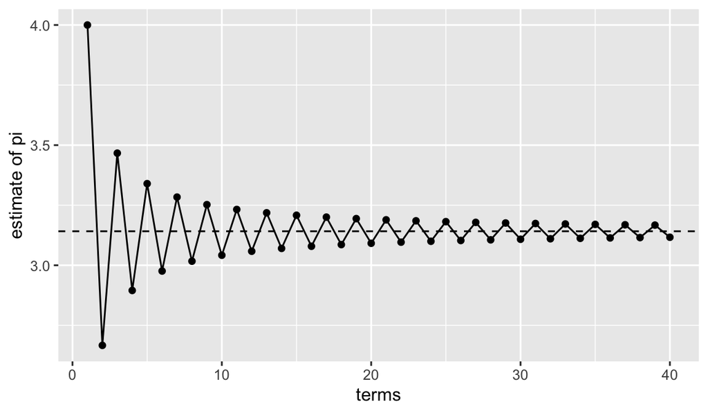

```r
tibble(n = 1:40, estimate = map_dbl(n, S)) |>
  ggplot(aes(x = n, y = estimate)) +
  geom_hline(yintercept = pi, linetype = "dashed") +
  geom_point() +
  geom_line() +
  labs(x = "terms", y = "estimate of pi")
```

The alternation, drawn. `+` adds layers; the dashed line is a geometry with no data of its own.

That axis cannot show convergence. **Errors spanning orders of magnitude belong on log axes**, where error $\propto n^{-p}$ is a straight line of slope $-p$:

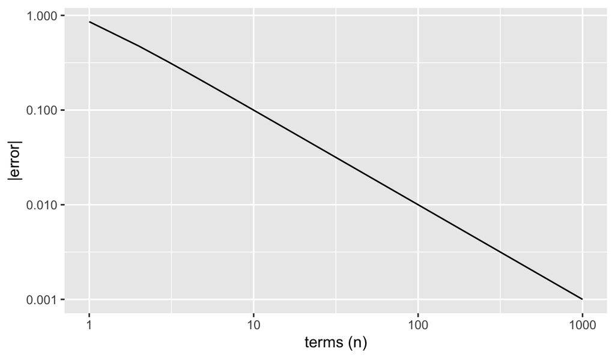

```r
ggplot(convergence, aes(x = n, y = error)) +
  geom_line() +
  scale_x_log10() +
  scale_y_log10() +
  labs(x = "terms (n)", y = "|error|")
```

Aesthetics other than position carry more variables. Which ones a geometry understands is on its help page (`?geom_point`):

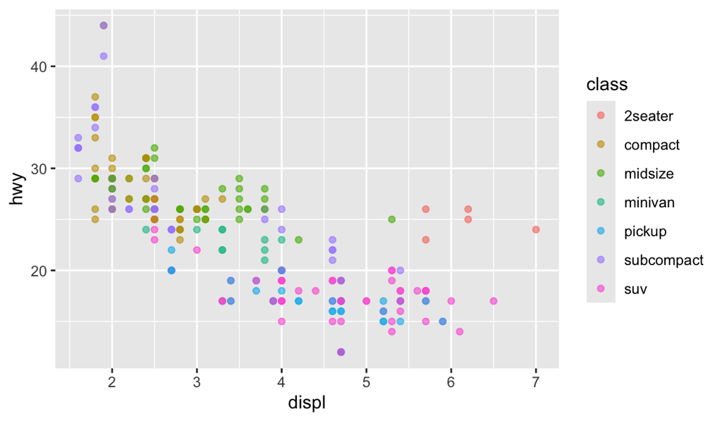

```r
ggplot(mpg, aes(x = displ, y = hwy, color = class)) +
  geom_point(alpha = 0.6)
```

A **histogram** bins one variable. Constants rather than data go *outside* `aes()`:

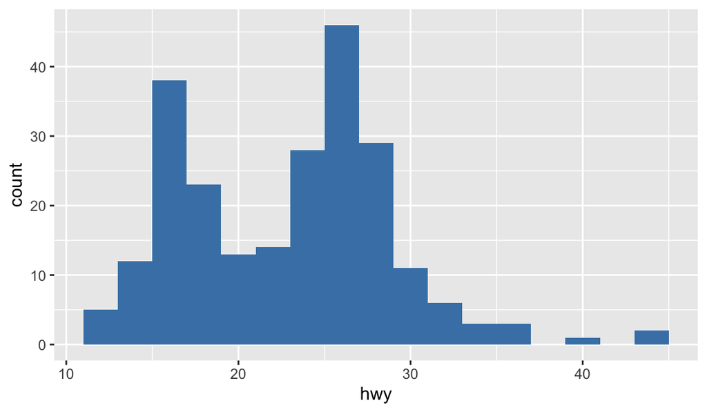

```r
ggplot(mpg, aes(x = hwy)) +
  geom_histogram(binwidth = 2, fill = "steelblue")
```

**Facets** split a plot into small multiples — usually better than another colour:

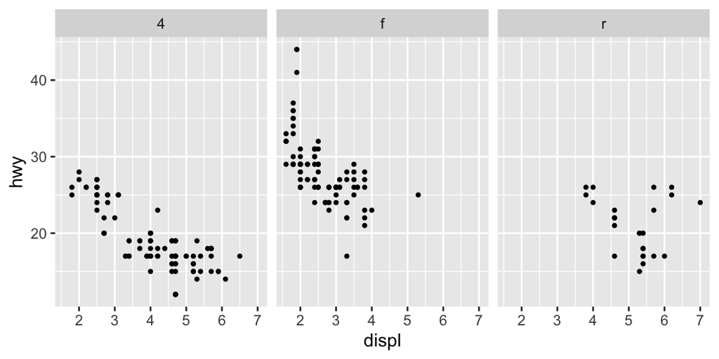

```r
ggplot(mpg, aes(x = displ, y = hwy)) +
  geom_point(size = 0.8) +
  facet_wrap(~ drv)
```

## Exercise

Two plots of `starwars`.

**(a)** A scatter plot of `height` against `mass`. One point will ruin it — name the character, then plot it again without that row and say what you can see now that you could not before.

**(b)** A histogram of `height`, with a `binwidth` you can defend. What does the shape tell you that `mean(height)` would not?

**Expected output:**

| heaviest character | Jabba Desilijic Tiure, 1358 kg |
| --- | --- |
| next heaviest | Grievous, 159 kg |
| median height | 180 cm |
| height range | 66–264 cm |
| characters under 100 cm | 7 |

### Solution

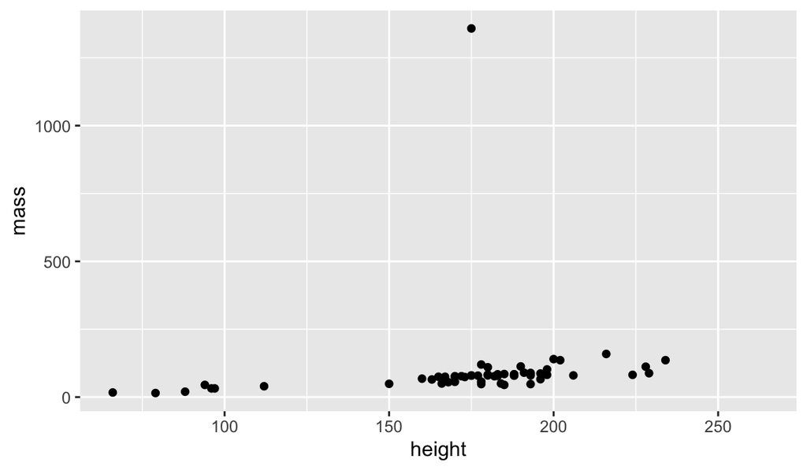

```r
ggplot(starwars, aes(x = height, y = mass)) + geom_point()
```

```r
slice_max(starwars, mass, n = 2) |> select(name, height, mass)
```

```
#> # A tibble: 2 × 3
#>   name                  height  mass
#>   <chr>                  <int> <dbl>
#> 1 Jabba Desilijic Tiure    175  1358
#> 2 Grievous                 216   159
```

Jabba is 8.5 times the mass of the next heaviest character, so the axis has to span a range that leaves every other point in one corner. Drop him and the relationship appears:

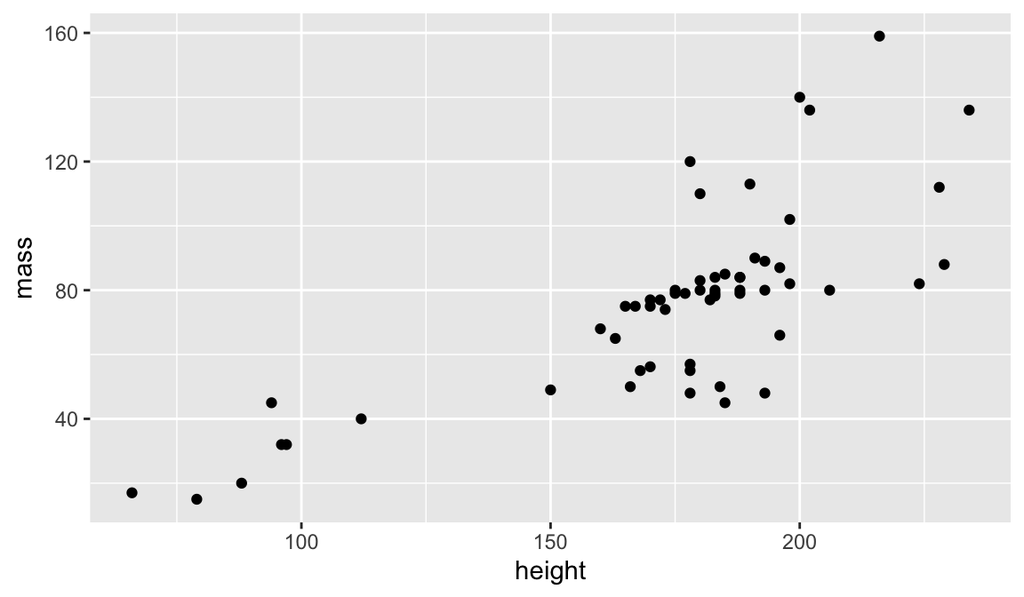

```r
starwars |>
  filter(mass < 1000) |>
  ggplot(aes(x = height, y = mass)) +
  geom_point()
```

One observation was hiding an obvious linear trend. This is a preview of a theme in the course: a single extreme value can dominate a computation as completely as it dominates this figure.

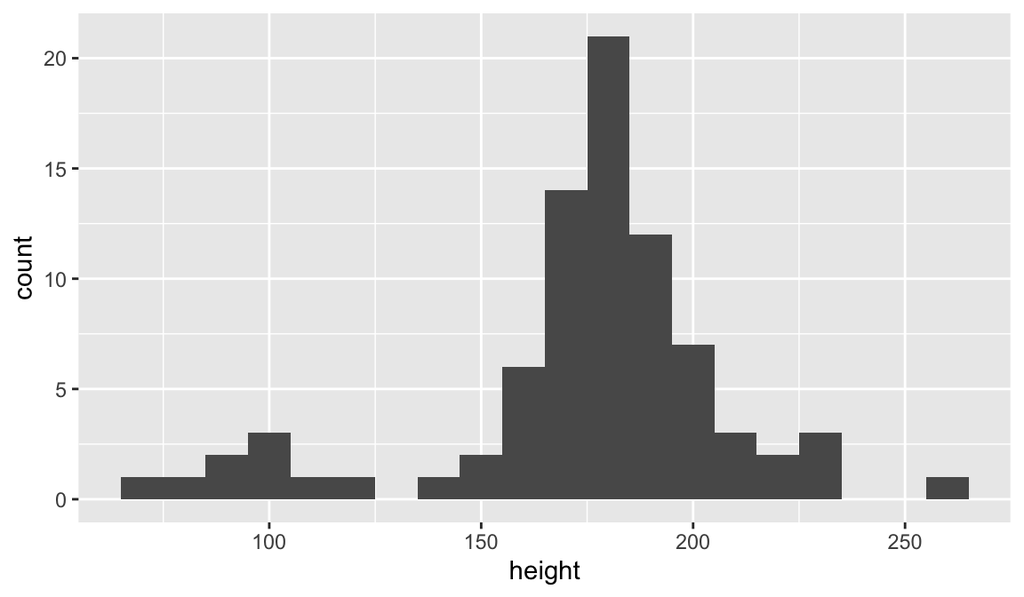

```r
ggplot(starwars, aes(x = height)) + geom_histogram(binwidth = 10)
```